111— title: “MSDS6306 Case Study 1” author: “Joe Schueder& Kyle Thomas” date: “October 6, 2017” output: html_document Location: “https://github.com/khthomas/DDS_CS1” —

#### Market for New Craft Brewery Market in the United States.

##### Prepared by Joe Scheder and Kyle Thomas for New Brewery Inc.

New Brewery Inc. would like to introduce a new IPA with a high alcohol content and bitterness. They would like to introduce this to a large market that currently favors having breweries producing beers with these characteristics.

The analysis is shown below.

```r
getwd()
```

```
## [1] "C:/Users/jjschued/Documents/casestudy16306/rmarkdown"
```

```r
setwd ("C:\\Users\\jjschued\\Downloads\\DDS_CS1-master\\DDS_CS1-master\\Data\\")
beers <- read.csv(file = "Beers.csv", sep=",", header=TRUE)
breweries <- read.csv(file = "Breweries.csv", sep=",", header=TRUE)

#Bring in additional population data. Via Us Cencus (https://www.census.gov/data/tables/2016/demo/popest/state-total.html)
uspop = read.csv("uspop.csv")
colnames(uspop) = c("State_Name", "State", "pop2016")

# #head(beers)
# colnames(beers)[5] <- "Brewery_ID"
# kable(head(beers), "html", padding = 2, longtable = TRUE) %>%
# kable_styling(bootstrap_options = "striped", full_width = F, position = "left")
#
# #head(breweries)
# colnames(breweries)[1] <- "Brewery_ID"
# kable(head(breweries), "html", padding = 2, longtable = TRUE) %>%
# kable_styling(bootstrap_options = "striped", full_width = F, position = "left")
```

First the number of breweries in each state was found. This will help identify geographic areas where the market is not saturated with many breweries. The number of breweries that are present in each state:

```r
Statesum <- count(breweries, 'State')
Statesum <- Statesum[order(-Statesum$freq),]
colnames(Statesum) <- c("State", "Number of Breweries")
kable(Statesum, "html", padding = 2, longtable = TRUE, row.names=FALSE) %>%
kable_styling(bootstrap_options = "striped", full_width = F, position = "left" )
```

| State | Number of Breweries |
| --- | --- |
| CO | 47 |
| CA | 39 |
| MI | 32 |
| OR | 29 |
| TX | 28 |
| PA | 25 |
| MA | 23 |
| WA | 23 |
| IN | 22 |
| WI | 20 |
| NC | 19 |
| IL | 18 |
| NY | 16 |
| VA | 16 |
| FL | 15 |
| OH | 15 |
| MN | 12 |
| AZ | 11 |
| VT | 10 |
| ME | 9 |
| MO | 9 |
| MT | 9 |
| CT | 8 |
| AK | 7 |
| GA | 7 |
| MD | 7 |
| OK | 6 |
| IA | 5 |
| ID | 5 |
| LA | 5 |
| NE | 5 |
| RI | 5 |
| HI | 4 |
| KY | 4 |
| NM | 4 |
| SC | 4 |
| UT | 4 |
| WY | 4 |
| AL | 3 |
| KS | 3 |
| NH | 3 |
| NJ | 3 |
| TN | 3 |
| AR | 2 |
| DE | 2 |
| MS | 2 |
| NV | 2 |
| DC | 1 |
| ND | 1 |
| SD | 1 |
| WV | 1 |

Secondly, data integrity checks were done. See the first 6 observations and the last six observations of the data.

```r
colnames(beers)[5] <- "Brewery_ID"
colnames(breweries)[1] <- "Brewery_ID"
beerandbrew <- merge(breweries, beers, by=c("Brewery_ID"), all= FALSE)
colnames(beerandbrew)[2] <- "Brewery"
colnames(beerandbrew)[5] <- "Beer"

#head(beerandbrew)

kable(head(beerandbrew), "html", padding = 2, longtable = TRUE) %>%
kable_styling(bootstrap_options = "striped", full_width = F, position = "left")
```

| Brewery_ID | Brewery | City | State | Beer | Beer_ID | ABV | IBU | Style | Ounces |
| --- | --- | --- | --- | --- | --- | --- | --- | --- | --- |
| 1 | NorthGate Brewing | Minneapolis | MN | Pumpion | 2689 | 0.060 | 38 | Pumpkin Ale | 16 |
| 1 | NorthGate Brewing | Minneapolis | MN | Stronghold | 2688 | 0.060 | 25 | American Porter | 16 |
| 1 | NorthGate Brewing | Minneapolis | MN | Parapet ESB | 2687 | 0.056 | 47 | Extra Special / Strong Bitter (ESB) | 16 |
| 1 | NorthGate Brewing | Minneapolis | MN | Get Together | 2692 | 0.045 | 50 | American IPA | 16 |
| 1 | NorthGate Brewing | Minneapolis | MN | Maggie’s Leap | 2691 | 0.049 | 26 | Milk / Sweet Stout | 16 |
| 1 | NorthGate Brewing | Minneapolis | MN | Wall’s End | 2690 | 0.048 | 19 | English Brown Ale | 16 |

```r
#tail(beerandbrew)
kable(tail(beerandbrew), "html", padding = 2, longtable = TRUE) %>%
kable_styling(bootstrap_options = "striped", full_width = F, position = "left")
```

|  | Brewery_ID | Brewery | City | State | Beer | Beer_ID | ABV | IBU | Style | Ounces |
| --- | --- | --- | --- | --- | --- | --- | --- | --- | --- | --- |
| 2405 | 556 | Ukiah Brewing Company | Ukiah | CA | Pilsner Ukiah | 98 | 0.055 | NA | German Pilsener | 12 |
| 2406 | 557 | Butternuts Beer and Ale | Garrattsville | NY | Porkslap Pale Ale | 49 | 0.043 | NA | American Pale Ale (APA) | 12 |
| 2407 | 557 | Butternuts Beer and Ale | Garrattsville | NY | Snapperhead IPA | 51 | 0.068 | NA | American IPA | 12 |
| 2408 | 557 | Butternuts Beer and Ale | Garrattsville | NY | Moo Thunder Stout | 50 | 0.049 | NA | Milk / Sweet Stout | 12 |
| 2409 | 557 | Butternuts Beer and Ale | Garrattsville | NY | Heinnieweisse Weissebier | 52 | 0.049 | NA | Hefeweizen | 12 |
| 2410 | 558 | Sleeping Lady Brewing Company | Anchorage | AK | Urban Wilderness Pale Ale | 30 | 0.049 | NA | English Pale Ale | 12 |

An additonal check of data was completed to make sure that data was present for most of the data being analyzed. The number of blanks in each column is shown. Overal there are 2,400 beers being made in the United States. Data was present for 97.5% of the beers for ABV. For IBU Data was missing in 40% of the beers.

```r
#colSums(is.na(beerandbrew))
kable(colSums(is.na(beerandbrew)), "html", padding = 2, longtable = TRUE) %>%
kable_styling(bootstrap_options = "striped", full_width = F, position = "left")
```

| Brewery_ID | 0 |
| --- | --- |
| Brewery | 0 |
| City | 0 |
| State | 0 |
| Beer | 0 |
| Beer_ID | 0 |
| ABV | 62 |
| IBU | 1005 |
| Style | 0 |
| Ounces | 0 |

In order to find the right market for the new beer. The median alcohol content and international bitterness unit was computed for each state. Data is visualized in bar charts.

```r
library("reshape2")
abvandibu <- aggregate(beerandbrew[, 7:8], list(beerandbrew$State), median, na.rm=TRUE)
abvandibu$ABV = abvandibu$ABV*100

abvandibumelt <- melt(abvandibu, id=c("Group.1"))
abvandibumelt <-abvandibumelt[order(-abvandibumelt$variable),]
```

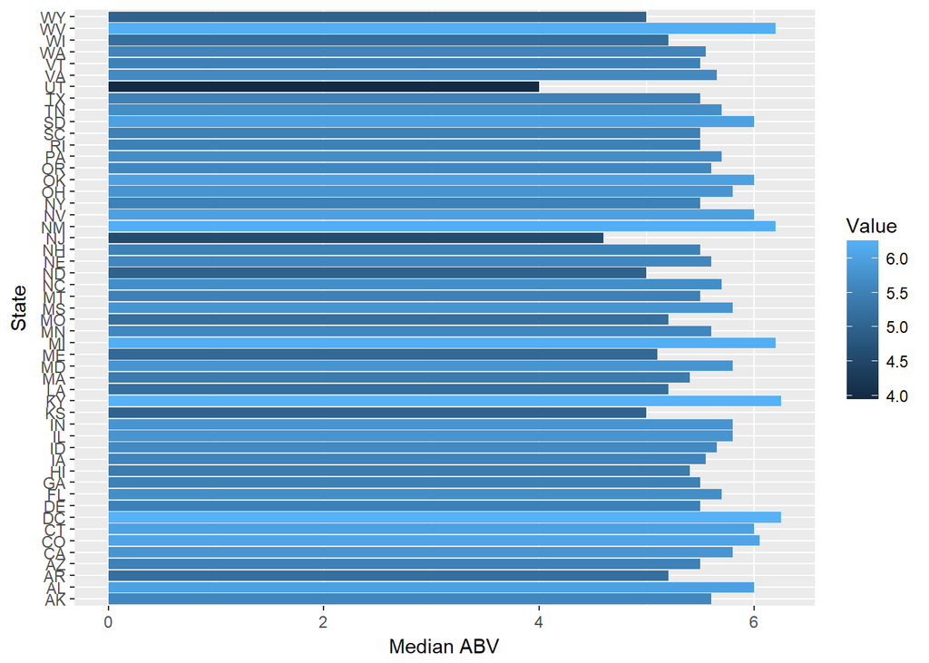

```r
colnames(abvandibumelt) <- c("State", "ABVIBU", "Value")

ABVMED <- abvandibumelt[abvandibumelt$ABVIBU == "ABV", ]
IBUMED <- abvandibumelt[abvandibumelt$ABVIBU == "IBU", ]

library("ggplot2")
qplot(x=State, data=ABVMED, geom ="bar", weight = Value, fill = Value, ylab = 'Median ABV') + coord_flip()
```

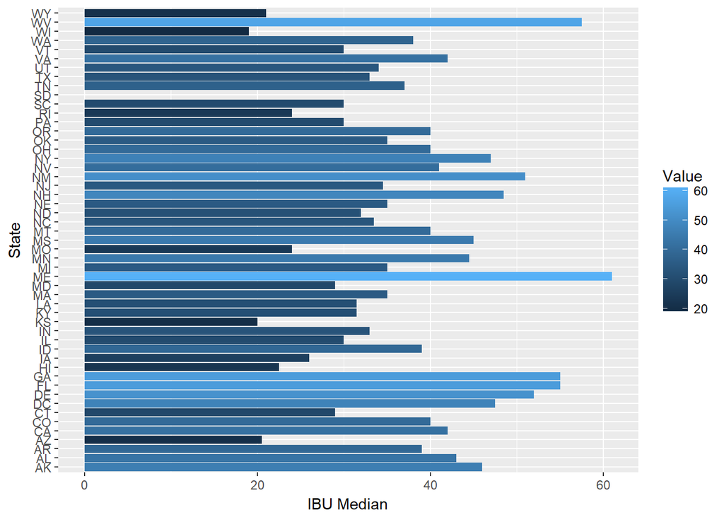

```r
qplot(x=State, data=IBUMED, geom ="bar", weight=Value, fill = Value, ylab = 'IBU Median') + coord_flip()
```

The state that has the maximum alcoholic (ABV) beer:

```r
maxabv <- beerandbrew[which.max(beerandbrew$ABV),]
#maxabv$State
kable(maxabv$State, "html", padding = 2, longtable = TRUE) %>%
kable_styling(bootstrap_options = "striped", full_width = F, position = "left")
```

| CO |
| --- |

The state that has the most bitter (IBU) beer:

```r
 maxibu <- beerandbrew[which.max(beerandbrew$IBU),]
#maxibu$State
kable(maxibu$State, "html", padding = 2, longtable = TRUE) %>%
kable_styling(bootstrap_options = "striped", full_width = F, position = "left")
```

| OR |
| --- |

A summary statistics table for the alcholic content in beers.

```r
sumtable <- summary(beerandbrew$ABV)
Statistics <- c("Min.", "1st Qu.",  "Median", "Mean", "3rd Qu.", "Max.", "NA's" )
Values <- c(sumtable[1], sumtable[2],  sumtable[3], sumtable[4], sumtable[5], sumtable[6], sumtable[7] )
sumdf <- data.frame(Statistics, Values)
kable(sumdf[2], "html", padding = 2, longtable = TRUE) %>%
kable_styling(bootstrap_options = "striped", full_width = F, position = "left")
```

|  | Values |
| --- | --- |
| Min. | 0.0010000 |
| 1st Qu. | 0.0500000 |
| Median | 0.0560000 |
| Mean | 0.0597734 |
| 3rd Qu. | 0.0670000 |
| Max. | 0.1280000 |
| NA’s | 62.0000000 |

Shown now is the apparent relationship between the bitterness of the beer and its alcoholic content.

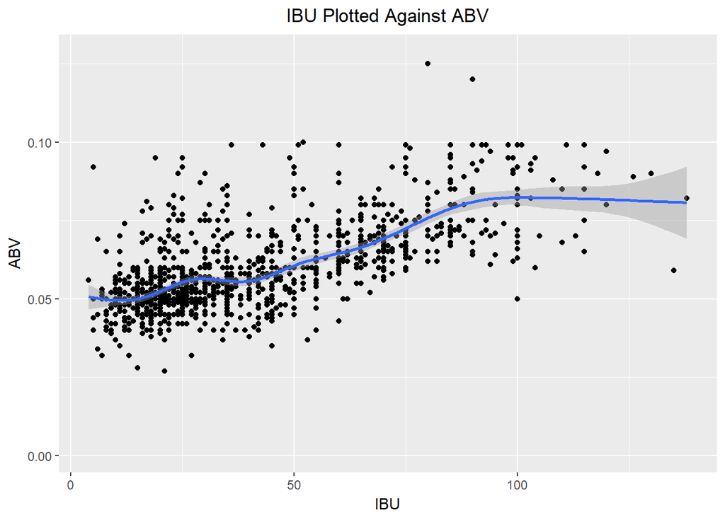

```r
#Changed old scatter plot to ggplot
# scatter.smooth(beerandbrew$ABV, beerandbrew$IBU, ylab = "IBU",
#                xlab = "ABV", col= 4, main = "ABV vs IBU")


ggScatter = ( ggplot(beerandbrew, aes(x=IBU, y=ABV)) + geom_point() +
                labs(title="IBU Plotted Against ABV") + theme(plot.title = element_text(hjust = 0.5)) +
                geom_smooth())

ggScatter
```

In order to identify a target market a combined metric for IBU and ABV was created. The new metric was simply the result of multiplying ABV with IBU. Next, the top states with the lowest median IBU and ABV beers were identified with the combined metric.

```r
#Merge us population with main dataframe

beerandbrew = merge(beerandbrew, uspop, by = "State")

#We need a way to compare IBU and ABV at the same time. This can be done by simply multiplying together
#IBU and ABV to make a combined measure.

colnames(abvandibu) = c("State", "ABV", "IBU")

needBeer = merge(abvandibu, uspop, by="State")
needBeer["combined"]= needBeer$IBU*needBeer$ABV

#Based only on a ABV and IBU
mostneeded = head(needBeer[order(needBeer$combined),],10)


#mostneeded
kable(mostneeded, "html", padding = 2, longtable = TRUE,row.names=FALSE) %>%
kable_styling(bootstrap_options = "striped", full_width = F, position = "left")
```

| State | ABV | IBU | State_Name | pop2016 | combined |
| --- | --- | --- | --- | --- | --- |
| WI | 5.20 | 19.0 | .Wisconsin | 5,778,708 | 98.80 |
| KS | 5.00 | 20.0 | .Kansas | 2,907,289 | 100.00 |
| WY | 5.00 | 21.0 | .Wyoming | 585,501 | 105.00 |
| AZ | 5.50 | 20.5 | .Arizona | 6,931,071 | 112.75 |
| HI | 5.40 | 22.5 | .Hawaii | 1,428,557 | 121.50 |
| MO | 5.20 | 24.0 | .Missouri | 6,093,000 | 124.80 |
| RI | 5.50 | 24.0 | .Rhode Island | 1,056,426 | 132.00 |
| UT | 4.00 | 34.0 | .Utah | 3,051,217 | 136.00 |
| IA | 5.55 | 26.0 | .Iowa | 3,134,693 | 144.30 |
| NJ | 4.60 | 34.5 | .New Jersey | 8,944,469 | 158.70 |

```r
#highest Populations - this part of the analysis was scrapped
# needAndPop = tail(mostneeded[order(mostneeded$pop2016),],3)
#
# needAndPop
```

Below is a map of the United States that shows the combined ABV and IBU metric as a heat map. States that have higher median ABV and IBU beers are warmer in color. States that have lower median ABV and IBU beers are cooler in color. This graphic is particularly helpful for visualizing regional preferences and determining where a new brewery should be located.

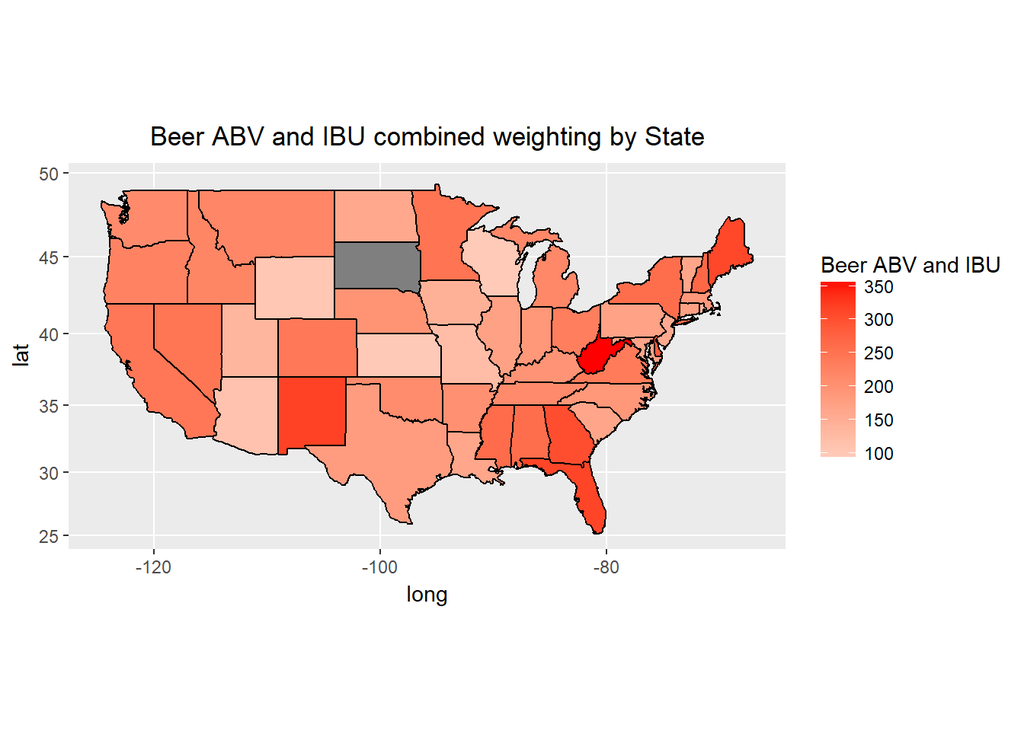

```r
#I ended up redoing this section for only median data. I kept the code in the script for histroical reasons
# beerandbrew$State_Name = tolower(beerandbrew$State_Name)
# beerandbrew$State_Name = sub(".","", beerandbrew$State_Name)
# colnames(beerandbrew)[11] = "region"
#
# stateMap = map_data("state")
# mapdf = merge(stateMap, beerandbrew, by="region")
# mapdf["combined"] = mapdf$ABV*mapdf$IBU
# mapdf = mapdf[order(mapdf$order),]
#
# #Right now this is IBU, I will change it to what ever metrix we want to evaluate target states.
# #Thanks stackoverflow
# ggplot(mapdf, aes(x=long,y=lat,group=group))+
#   geom_polygon(aes(fill=IBU))+
#   geom_path()+
#   #scale_fill_gradientn(colours=rev(heat.colors(10)),na.value="grey50")+
#   scale_fill_gradient2(low="blue", mid="white", high="red", na.value="grey50", space="Lab", guide="colourbar")+
#   coord_map()

####MEDIAN ONLY DATA#####
needBeer$State_Name = tolower(needBeer$State_Name)
needBeer$State_Name = sub(".", "", needBeer$State_Name)
colnames(needBeer)[4] = "region"
stateMap2 = map_data("state")
mapdf2 = data.frame(merge(stateMap2, needBeer, by="region"), stringsAsFactors = FALSE)

#This was an attempt to only show the three selected states.... more trouble than it was worth
# for (x in 1:nrow(mapdf2)) {
#
# if(! mapdf2[7,x]  %in% c(" NJ", " MO", " AZ"))  {
#   mapdf2[11,x] = ""}
#
#   #else {mapdf2[11,x] = mapdf2[11,x]}
#
# }



ggplot(mapdf2, aes(x=long,y=lat,group=group))+
  geom_polygon(aes(fill=combined))+
  geom_path()+
  #scale_fill_gradientn(colours=rev(heat.colors(10)),na.value="grey50")+
  scale_fill_gradient2(low="blue", mid="white", high="red", na.value="grey50", space="Lab", guide="colourbar")+
  labs(fill="Beer ABV and IBU", title="Beer ABV and IBU combined weighting by State", xlab="", ylab="")+
  theme(plot.title = element_text(hjust = 0.5))+
  coord_map()
```

Based on the analysis of the data for breweries by state, there is reason to believe that there are certain states that have a lack of high median alcohol content and bitter beers.

A basic market analysis was conducted to determine which states could use a high ABV and high IBU beer. The 3 states with the lowest median IBU and ABV beers were identified (via the combined metric). The three states with the lowest combined ABV and IBU values are Wisconsin, Kansas, and Wyoming. Interestingly, these states are within a reasonable trucking distance, so this new brewery could be located in a low cost area and the beer could be shipped to these identified states.